# Association Analyses with IBIS Data: Correlation and Linear Regression Analyses

Kevin Donovan

January 27, 2021

# Introduction

**Previous Session**: introduced concepts in statistical inference

**Now**: focus on analytic methods and their implementation in R

# Multivariable Analysis

**Previously**: Discussed simple univariable analyses (comparing means)

Suppose one is interested in how multiple variables are **related distributionally**

**Simplest case**: Two variables $X$ and $Y$

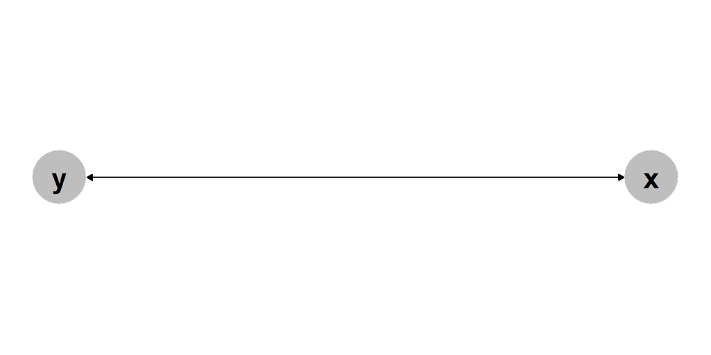

# Covariance and Correlation

**Covariance**: $\text{Cov}(X, Y)=\text{E}[(X-\text{E}[X])(Y-\text{E}[Y])]$

Looking inside the outer mean: $(X-\text{E}[X])(Y-\text{E}[Y])$

- Can see $>0$ means both variables in **same direction vs. average**
- $<0$ means both variables in **different directions vs. average**

**Limitation**: relationship size in terms of variable units

**Pearson Correlation**: $\text{Corr}(X, Y)=\frac{\text{Cov}(X,Y)}{\sqrt{\text{Var}(X)}\sqrt{\text{Var}(Y)}}$

**Standardizes** relationship size using variances

# Covariance visual explanation

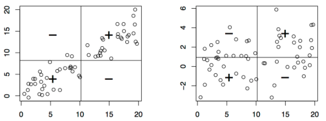

# Correlation in IBIS

```{=html}

| x_var | y_var | estimate | p.value |
| --- | --- | --- | --- |
| V06 MSEL Composite SS | V06 AOSI Raw TS | -0.366 | <0.005 |
| V12 MSEL Composite SS | V12 AOSI Raw TS | -0.296 | <0.005 |

```

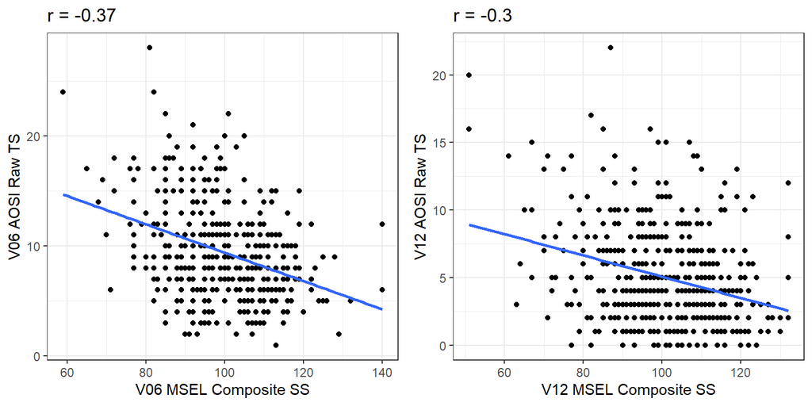

# Correlation: Assessing Significance

# Correlation Estimates: Example

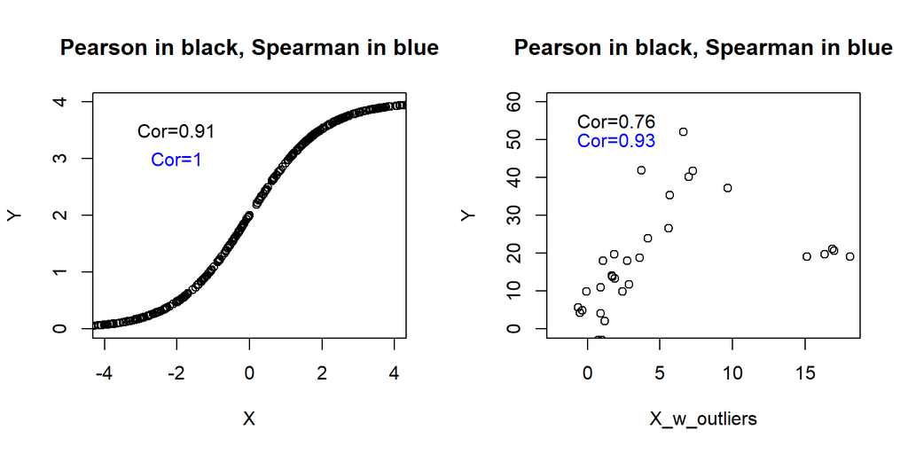

# Limitations of Correlation

- Assesses how well $X$ and $Y$ “tie together”, clinical effect size not well represented
- Only assessses linear or monotonic association
- Adding “confounders” to relationship not straight-forward
- **Doesn’t look at mean/median comparisons**

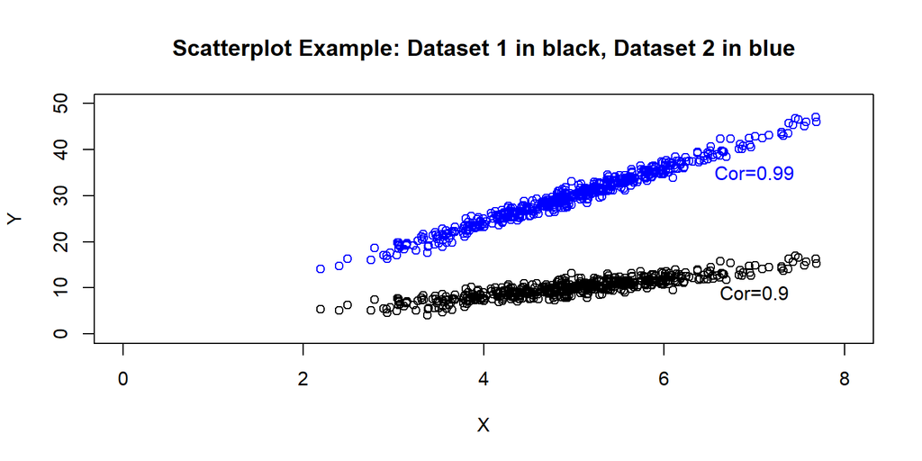

# Linear Regression: Setup

Consider variable $X$ and $Y$ again

Consider a **directional** relationship:

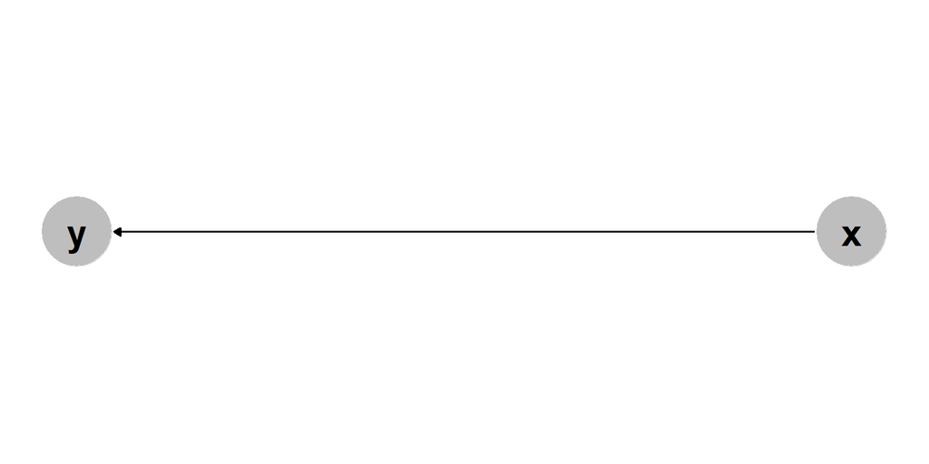

$X$ denoted *independent variable*; $Y$ denoted *dependent variable*

$X$ and $Y$ related **through mean**: $\text{E}(Y|X)=\beta_0+\beta_1X$

# Linear Regression: Setup

**Full Model**:
$$\begin{align}
&Y=\beta_0+\beta_1X+\epsilon \\
&\\
&\text{where E}(\epsilon)=0 \text{; Var}(\epsilon)=\sigma^2 \\
&\epsilon_i \perp \epsilon_j \text{ for }i\neq j; X\perp \epsilon
\end{align}$$

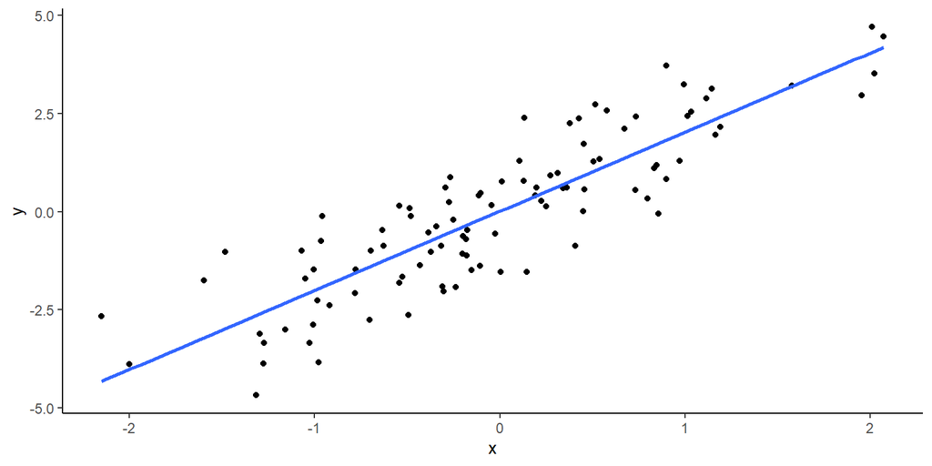

# Linear Regression: Inference

**Estimation**:

Find “line of best fit” in data

- Let $\hat{Y_i}=\hat{\beta_0}+\hat{\beta_1}X_i$
- Define *sum of the squared error* $(SSE) = \sum_{i=1}^{n}(\hat{Y_i}-Y_i)^2$
- **Goal**: find $\hat{\beta_0}$ and $\hat{\beta_1}$ which minimize $SSE$
- With single $X$, have
  1. $\hat{\beta_1}=r_{xy}\frac{\hat{\sigma_y}}{\hat{\sigma_x}}$
  2. $\hat{\beta_0}=\bar{Y}-\hat{\beta}\bar{X}$

Can see slope estimate is **scaled correlation**

- $\hat{\beta_0}=\hat{\text{E}}(Y|X=0)$
- $\hat{\beta_1}=\hat{\text{E}}(Y|X=x+1)-\hat{\text{E}}(Y|X=x) \text{ for any }x$

# Linear Regression: Inference

**Confidence Intervals and Testing**:

1. If $\epsilon_i \perp \epsilon_j$ for $i \neq j$ and $\epsilon \sim\text{Normal}(0,\sigma^2)$
- Under $H_0: \beta_p=0$ for $p=0,1$ can create test statistic with $T(n-2)$ distribution
- Use to construct $95\%$ CIs, do hypothesis testing for non-zero $\beta_p$
2. If $\epsilon_i \perp \epsilon_j$ for $i \neq j$ and $\text{Var}(\epsilon_i)=\sigma^2$ for all $i$
- Under $H_0: \beta_p=0$, can do same as above using CLT for “large” sample
- Due to finite sample with CLT, test statistic distribution is “approximate”

# Linear Regression: Covariates

Above all apply for general regression equation:

$Y=\beta_0+\beta_1X1+\ldots+\beta_pX_p+\epsilon$

Where $\text{E}(Y|X_1, \ldots, X_p)=\beta_0+\beta_1X1+\ldots+\beta_pX_p$

$Y|X_1, \ldots, X_p=$ “controlling for $X_1, \ldots, X_p$”

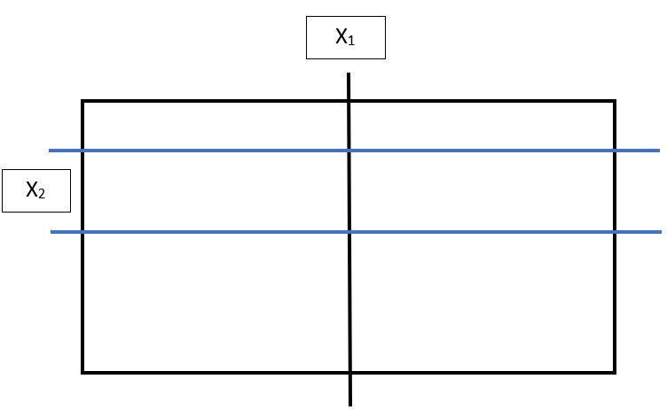

# Confounders

- Often illustrated using a DAG (directed acylic graph)

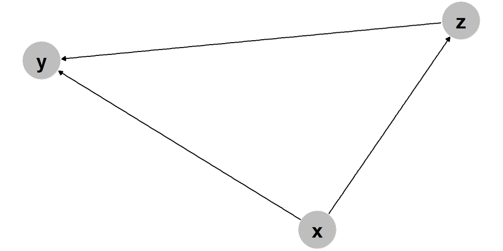

- X -> Y: $\Delta_x \text{E}(Y|X=x, Z=z)$
- X -> Z: $\Delta_x \text{E}(Z|X=x)$
- Z -> Y: $\Delta_z \text{E}(Y|Z=z)$

# Diagnostics

- **Recall**: Model has a number of assumptions
  - $\text{E}(Y|X_1, \ldots, X_p)=\beta_0+\beta_1X1+\ldots+\beta_pX_p$
  - $\epsilon_i \sim\text{Normal}(0,\sigma^2)$ for all $i$
  - $\epsilon_i \perp \epsilon_j$ for $i \neq j$
- Must evaluate if data violates assumptions
  - Generally, $H_0$: Assumptions are met

# Diagnostics

1. Normality
- Residual QQ-plot

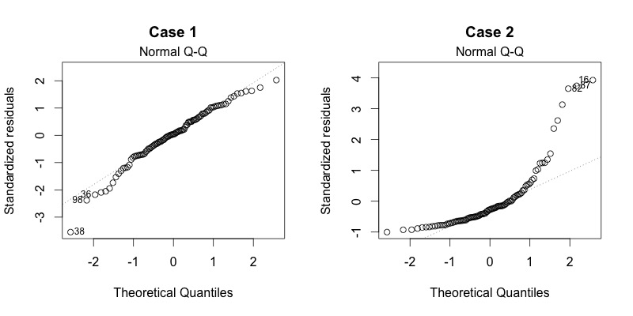

2. Homoskedasicity
- Residual by fitted value plot

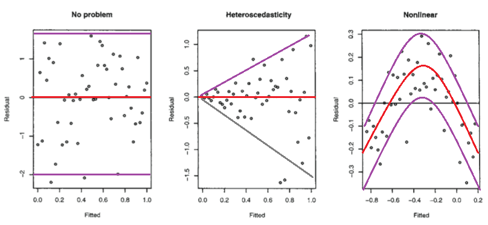